# Risk Factor Analysis

## Outcome Variable

**Outcome Variable:** pers_wasted624

## Predictor Variables

**Intervention Variable:** ever_sstunted06

**Adjustment Set:**

unadjusted

## Stratifying Variables

The analysis was stratified on these variable(s):

- studyid
- country

## Data Summary

| studyid | country | ever_sstunted06 | pers_wasted624 | n_cell | n | outcome_variable |
| --- | --- | --- | --- | --- | --- | --- |
| CMC-V-BCS-2002 | INDIA | 0 | 0 | 260 | 370 | pers_wasted624 |
| CMC-V-BCS-2002 | INDIA | 0 | 1 | 16 | 370 | pers_wasted624 |
| CMC-V-BCS-2002 | INDIA | 1 | 0 | 82 | 370 | pers_wasted624 |
| CMC-V-BCS-2002 | INDIA | 1 | 1 | 12 | 370 | pers_wasted624 |
| CMIN | BANGLADESH | 0 | 0 | 181 | 252 | pers_wasted624 |
| CMIN | BANGLADESH | 0 | 1 | 12 | 252 | pers_wasted624 |
| CMIN | BANGLADESH | 1 | 0 | 46 | 252 | pers_wasted624 |
| CMIN | BANGLADESH | 1 | 1 | 13 | 252 | pers_wasted624 |
| COHORTS | GUATEMALA | 0 | 0 | 843 | 1023 | pers_wasted624 |
| COHORTS | GUATEMALA | 0 | 1 | 24 | 1023 | pers_wasted624 |
| COHORTS | GUATEMALA | 1 | 0 | 139 | 1023 | pers_wasted624 |
| COHORTS | GUATEMALA | 1 | 1 | 17 | 1023 | pers_wasted624 |
| COHORTS | INDIA | 0 | 0 | 5774 | 6893 | pers_wasted624 |
| COHORTS | INDIA | 0 | 1 | 648 | 6893 | pers_wasted624 |
| COHORTS | INDIA | 1 | 0 | 348 | 6893 | pers_wasted624 |
| COHORTS | INDIA | 1 | 1 | 123 | 6893 | pers_wasted624 |
| COHORTS | PHILIPPINES | 0 | 0 | 2411 | 2809 | pers_wasted624 |
| COHORTS | PHILIPPINES | 0 | 1 | 184 | 2809 | pers_wasted624 |
| COHORTS | PHILIPPINES | 1 | 0 | 172 | 2809 | pers_wasted624 |
| COHORTS | PHILIPPINES | 1 | 1 | 42 | 2809 | pers_wasted624 |
| CONTENT | PERU | 0 | 0 | 207 | 215 | pers_wasted624 |
| CONTENT | PERU | 0 | 1 | 0 | 215 | pers_wasted624 |
| CONTENT | PERU | 1 | 0 | 8 | 215 | pers_wasted624 |
| CONTENT | PERU | 1 | 1 | 0 | 215 | pers_wasted624 |
| EE | PAKISTAN | 0 | 0 | 188 | 373 | pers_wasted624 |
| EE | PAKISTAN | 0 | 1 | 24 | 373 | pers_wasted624 |
| EE | PAKISTAN | 1 | 0 | 136 | 373 | pers_wasted624 |
| EE | PAKISTAN | 1 | 1 | 25 | 373 | pers_wasted624 |
| GMS-Nepal | NEPAL | 0 | 0 | 454 | 590 | pers_wasted624 |
| GMS-Nepal | NEPAL | 0 | 1 | 88 | 590 | pers_wasted624 |

[output cut: 90 more lines]

The following strata were considered:

- studyid: CMC-V-BCS-2002, country: INDIA
- studyid: CMIN, country: BANGLADESH
- studyid: COHORTS, country: GUATEMALA
- studyid: COHORTS, country: INDIA
- studyid: COHORTS, country: PHILIPPINES
- studyid: CONTENT, country: PERU
- studyid: EE, country: PAKISTAN
- studyid: GMS-Nepal, country: NEPAL
- studyid: Guatemala BSC, country: GUATEMALA
- studyid: IRC, country: INDIA
- studyid: JiVitA-3, country: BANGLADESH
- studyid: JiVitA-4, country: BANGLADESH
- studyid: Keneba, country: GAMBIA
- studyid: LCNI-5, country: MALAWI
- studyid: MAL-ED, country: BANGLADESH
- studyid: MAL-ED, country: BRAZIL
- studyid: MAL-ED, country: INDIA
- studyid: MAL-ED, country: NEPAL
- studyid: MAL-ED, country: PERU
- studyid: MAL-ED, country: SOUTH AFRICA
- studyid: MAL-ED, country: TANZANIA, UNITED REPUBLIC OF
- studyid: NIH-Birth, country: BANGLADESH
- studyid: NIH-Crypto, country: BANGLADESH
- studyid: PROBIT, country: BELARUS
- studyid: PROVIDE, country: BANGLADESH
- studyid: ResPak, country: PAKISTAN
- studyid: SAS-CompFeed, country: INDIA
- studyid: SAS-FoodSuppl, country: INDIA
- studyid: TanzaniaChild2, country: TANZANIA, UNITED REPUBLIC OF
- studyid: ZVITAMBO, country: ZIMBABWE

### Dropped Strata

Some strata were dropped due to rare outcomes:

- studyid: CONTENT, country: PERU
- studyid: Guatemala BSC, country: GUATEMALA
- studyid: LCNI-5, country: MALAWI
- studyid: MAL-ED, country: BANGLADESH
- studyid: MAL-ED, country: BRAZIL
- studyid: MAL-ED, country: NEPAL
- studyid: MAL-ED, country: PERU
- studyid: MAL-ED, country: SOUTH AFRICA
- studyid: MAL-ED, country: TANZANIA, UNITED REPUBLIC OF
- studyid: PROBIT, country: BELARUS
- studyid: PROVIDE, country: BANGLADESH

## Methods Detail

We’re interested in the causal parameters $E[Y_a]$ for all values of $a \in \mathcal{A}$. These parameters represent the mean outcome if, possibly contrary to fact, we intervened to set all units to have $A=a$. Under the randomization and positivity assumptions, these are identified by the statistical parameters $\psi_a=E_W[E_{Y|A,W}(Y|A=a,W)]$. In addition, we’re interested in the mean of $Y$, $E[Y]$ under no intervention (the observed mean). We will estimate these parameters by using SuperLearner to fit the relevant likelihood factors – $E_{Y|A,W}(Y|A=a,W)$ and $p(A=a|W)$, and then updating our likelihood fit using a joint TMLE.

For unadjusted analyses ($W=\{\}$), initial likelihoods were estimated using Lrnr_glm to estimate the simple $E(Y|A)$ and Lrnr_mean to estimate $p(A)$. For adjusted analyses, a small library containing Lrnr_glmnet, Lrnr_xgboost, and Lrnr_mean was used.

Having estimated these parameters, we will then use the delta method to estimate relative risks and attributable risks relative to a prespecified baseline level of $A$.

# Results Detail

## Results Plots

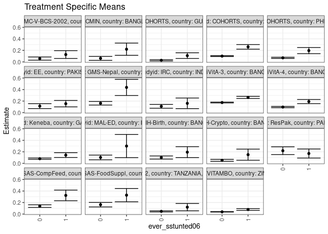

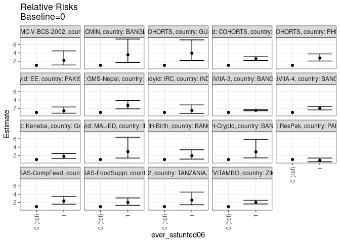

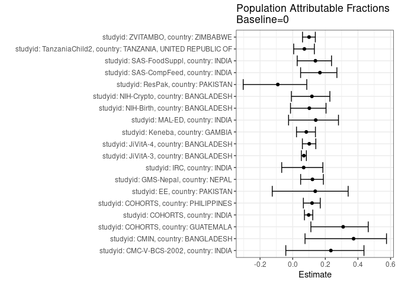

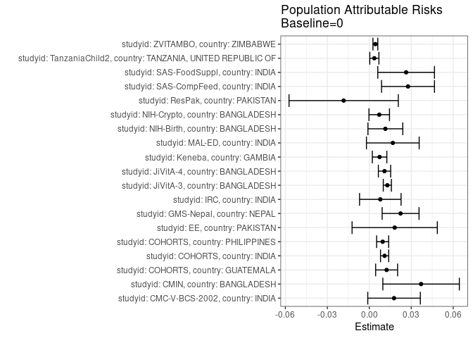

## Results Table

### Parameter: TSM

| studyid | country | intervention_level | baseline_level | estimate | ci_lower | ci_upper |
| --- | --- | --- | --- | --- | --- | --- |
| CMC-V-BCS-2002 | INDIA | 0 | NA | 0.0579710 | 0.0303640 | 0.0855780 |
| CMC-V-BCS-2002 | INDIA | 1 | NA | 0.1276596 | 0.0601071 | 0.1952121 |
| CMIN | BANGLADESH | 0 | NA | 0.0621762 | 0.0280407 | 0.0963116 |
| CMIN | BANGLADESH | 1 | NA | 0.2203390 | 0.1143687 | 0.3263093 |
| COHORTS | GUATEMALA | 0 | NA | 0.0276817 | 0.0167559 | 0.0386074 |
| COHORTS | GUATEMALA | 1 | NA | 0.1089744 | 0.0600522 | 0.1578965 |
| COHORTS | INDIA | 0 | NA | 0.1009031 | 0.0935360 | 0.1082703 |
| COHORTS | INDIA | 1 | NA | 0.2611465 | 0.2214739 | 0.3008191 |
| COHORTS | PHILIPPINES | 0 | NA | 0.0709056 | 0.0610285 | 0.0807826 |
| COHORTS | PHILIPPINES | 1 | NA | 0.1962617 | 0.1430394 | 0.2494840 |
| EE | PAKISTAN | 0 | NA | 0.1132075 | 0.0704993 | 0.1559158 |
| EE | PAKISTAN | 1 | NA | 0.1552795 | 0.0992610 | 0.2112980 |
| GMS-Nepal | NEPAL | 0 | NA | 0.1623616 | 0.1312884 | 0.1934349 |
| GMS-Nepal | NEPAL | 1 | NA | 0.4375000 | 0.2970421 | 0.5779579 |
| IRC | INDIA | 0 | NA | 0.1091954 | 0.0763872 | 0.1420036 |
| IRC | INDIA | 1 | NA | 0.1612903 | 0.0696277 | 0.2529530 |
| JiVitA-3 | BANGLADESH | 0 | NA | 0.1748730 | 0.1679898 | 0.1817562 |
| JiVitA-3 | BANGLADESH | 1 | NA | 0.2640000 | 0.2453488 | 0.2826512 |
| JiVitA-4 | BANGLADESH | 0 | NA | 0.0963933 | 0.0854268 | 0.1073598 |
| JiVitA-4 | BANGLADESH | 1 | NA | 0.1919866 | 0.1561103 | 0.2278630 |
| Keneba | GAMBIA | 0 | NA | 0.0809477 | 0.0690683 | 0.0928271 |
| Keneba | GAMBIA | 1 | NA | 0.1428571 | 0.1013389 | 0.1843754 |
| MAL-ED | INDIA | 0 | NA | 0.1023256 | 0.0617274 | 0.1429237 |
| MAL-ED | INDIA | 1 | NA | 0.3000000 | 0.0987348 | 0.5012652 |
| NIH-Birth | BANGLADESH | 0 | NA | 0.1010526 | 0.0739230 | 0.1281822 |
| NIH-Birth | BANGLADESH | 1 | NA | 0.1940299 | 0.0992523 | 0.2888074 |
| NIH-Crypto | BANGLADESH | 0 | NA | 0.0531758 | 0.0362619 | 0.0700896 |
| NIH-Crypto | BANGLADESH | 1 | NA | 0.1509434 | 0.0544976 | 0.2473892 |
| ResPak | PAKISTAN | 0 | NA | 0.2191781 | 0.1519306 | 0.2864256 |
| ResPak | PAKISTAN | 1 | NA | 0.1704545 | 0.0917208 | 0.2491883 |
| SAS-CompFeed | INDIA | 0 | NA | 0.1380186 | 0.1151684 | 0.1608688 |
| SAS-CompFeed | INDIA | 1 | NA | 0.3236715 | 0.2311487 | 0.4161943 |
| SAS-FoodSuppl | INDIA | 0 | NA | 0.1627219 | 0.1233226 | 0.2021212 |
| SAS-FoodSuppl | INDIA | 1 | NA | 0.3281250 | 0.2129488 | 0.4433012 |
| TanzaniaChild2 | TANZANIA, UNITED REPUBLIC OF | 0 | NA | 0.0469239 | 0.0374573 | 0.0563904 |
| TanzaniaChild2 | TANZANIA, UNITED REPUBLIC OF | 1 | NA | 0.1200000 | 0.0562929 | 0.1837071 |
| ZVITAMBO | ZIMBABWE | 0 | NA | 0.0388923 | 0.0350331 | 0.0427516 |
| ZVITAMBO | ZIMBABWE | 1 | NA | 0.0793103 | 0.0637593 | 0.0948614 |

### Parameter: E(Y)

| studyid | country | intervention_level | baseline_level | estimate | ci_lower | ci_upper |
| --- | --- | --- | --- | --- | --- | --- |
| CMC-V-BCS-2002 | INDIA | NA | NA | 0.0756757 | 0.0486905 | 0.1026609 |
| CMIN | BANGLADESH | NA | NA | 0.0992063 | 0.0622241 | 0.1361886 |
| COHORTS | GUATEMALA | NA | NA | 0.0400782 | 0.0280529 | 0.0521035 |
| COHORTS | INDIA | NA | NA | 0.1118526 | 0.1044114 | 0.1192938 |
| COHORTS | PHILIPPINES | NA | NA | 0.0804557 | 0.0703953 | 0.0905161 |
| EE | PAKISTAN | NA | NA | 0.1313673 | 0.0970401 | 0.1656945 |
| GMS-Nepal | NEPAL | NA | NA | 0.1847458 | 0.1534039 | 0.2160876 |
| IRC | INDIA | NA | NA | 0.1170732 | 0.0859146 | 0.1482317 |
| JiVitA-3 | BANGLADESH | NA | NA | 0.1877787 | 0.1812440 | 0.1943134 |
| JiVitA-4 | BANGLADESH | NA | NA | 0.1072855 | 0.0967458 | 0.1178252 |
| Keneba | GAMBIA | NA | NA | 0.0882993 | 0.0766987 | 0.0998998 |
| MAL-ED | INDIA | NA | NA | 0.1191489 | 0.0776405 | 0.1606574 |
| NIH-Birth | BANGLADESH | NA | NA | 0.1125461 | 0.0859151 | 0.1391771 |
| NIH-Crypto | BANGLADESH | NA | NA | 0.0602740 | 0.0429977 | 0.0775502 |
| ResPak | PAKISTAN | NA | NA | 0.2008547 | 0.1494120 | 0.2522974 |
| SAS-CompFeed | INDIA | NA | NA | 0.1657061 | 0.1471754 | 0.1842367 |
| SAS-FoodSuppl | INDIA | NA | NA | 0.1890547 | 0.1507312 | 0.2273783 |
| TanzaniaChild2 | TANZANIA, UNITED REPUBLIC OF | NA | NA | 0.0505451 | 0.0409848 | 0.0601054 |
| ZVITAMBO | ZIMBABWE | NA | NA | 0.0432327 | 0.0393972 | 0.0470683 |

### Parameter: RR

| studyid | country | intervention_level | baseline_level | estimate | ci_lower | ci_upper |
| --- | --- | --- | --- | --- | --- | --- |
| CMC-V-BCS-2002 | INDIA | 0 | 0 | 1.0000000 | 1.0000000 | 1.000000 |
| CMC-V-BCS-2002 | INDIA | 1 | 0 | 2.2021277 | 1.0806113 | 4.487614 |
| CMIN | BANGLADESH | 0 | 0 | 1.0000000 | 1.0000000 | 1.000000 |
| CMIN | BANGLADESH | 1 | 0 | 3.5437853 | 1.7079938 | 7.352728 |
| COHORTS | GUATEMALA | 0 | 0 | 1.0000000 | 1.0000000 | 1.000000 |
| COHORTS | GUATEMALA | 1 | 0 | 3.9366987 | 2.1653406 | 7.157117 |
| COHORTS | INDIA | 0 | 0 | 1.0000000 | 1.0000000 | 1.000000 |
| COHORTS | INDIA | 1 | 0 | 2.5880907 | 2.1866466 | 3.063236 |
| COHORTS | PHILIPPINES | 0 | 0 | 1.0000000 | 1.0000000 | 1.000000 |
| COHORTS | PHILIPPINES | 1 | 0 | 2.7679297 | 2.0405807 | 3.754537 |
| EE | PAKISTAN | 0 | 0 | 1.0000000 | 1.0000000 | 1.000000 |
| EE | PAKISTAN | 1 | 0 | 1.3716356 | 0.8138475 | 2.311716 |
| GMS-Nepal | NEPAL | 0 | 0 | 1.0000000 | 1.0000000 | 1.000000 |
| GMS-Nepal | NEPAL | 1 | 0 | 2.6946023 | 1.8542646 | 3.915774 |
| IRC | INDIA | 0 | 0 | 1.0000000 | 1.0000000 | 1.000000 |
| IRC | INDIA | 1 | 0 | 1.4770798 | 0.7766418 | 2.809229 |
| JiVitA-3 | BANGLADESH | 0 | 0 | 1.0000000 | 1.0000000 | 1.000000 |
| JiVitA-3 | BANGLADESH | 1 | 0 | 1.5096669 | 1.3934896 | 1.635530 |
| JiVitA-4 | BANGLADESH | 0 | 0 | 1.0000000 | 1.0000000 | 1.000000 |
| JiVitA-4 | BANGLADESH | 1 | 0 | 1.9917011 | 1.5970639 | 2.483854 |
| Keneba | GAMBIA | 0 | 0 | 1.0000000 | 1.0000000 | 1.000000 |
| Keneba | GAMBIA | 1 | 0 | 1.7648084 | 1.2743851 | 2.443962 |
| MAL-ED | INDIA | 0 | 0 | 1.0000000 | 1.0000000 | 1.000000 |
| MAL-ED | INDIA | 1 | 0 | 2.9318182 | 1.3447391 | 6.391989 |
| NIH-Birth | BANGLADESH | 0 | 0 | 1.0000000 | 1.0000000 | 1.000000 |
| NIH-Birth | BANGLADESH | 1 | 0 | 1.9200871 | 1.0996430 | 3.352665 |
| NIH-Crypto | BANGLADESH | 0 | 0 | 1.0000000 | 1.0000000 | 1.000000 |
| NIH-Crypto | BANGLADESH | 1 | 0 | 2.8385744 | 1.3903512 | 5.795302 |
| ResPak | PAKISTAN | 0 | 0 | 1.0000000 | 1.0000000 | 1.000000 |
| ResPak | PAKISTAN | 1 | 0 | 0.7776989 | 0.4466696 | 1.354056 |
| SAS-CompFeed | INDIA | 0 | 0 | 1.0000000 | 1.0000000 | 1.000000 |
| SAS-CompFeed | INDIA | 1 | 0 | 2.3451291 | 1.5816306 | 3.477190 |
| SAS-FoodSuppl | INDIA | 0 | 0 | 1.0000000 | 1.0000000 | 1.000000 |
| SAS-FoodSuppl | INDIA | 1 | 0 | 2.0164773 | 1.3164388 | 3.088773 |
| TanzaniaChild2 | TANZANIA, UNITED REPUBLIC OF | 0 | 0 | 1.0000000 | 1.0000000 | 1.000000 |
| TanzaniaChild2 | TANZANIA, UNITED REPUBLIC OF | 1 | 0 | 2.5573333 | 1.4492309 | 4.512707 |
| ZVITAMBO | ZIMBABWE | 0 | 0 | 1.0000000 | 1.0000000 | 1.000000 |
| ZVITAMBO | ZIMBABWE | 1 | 0 | 2.0392276 | 1.6369155 | 2.540418 |

### Parameter: PAR

| studyid | country | intervention_level | baseline_level | estimate | ci_lower | ci_upper |
| --- | --- | --- | --- | --- | --- | --- |
| CMC-V-BCS-2002 | INDIA | 0 | NA | 0.0177047 | -0.0010918 | 0.0365011 |
| CMIN | BANGLADESH | 0 | NA | 0.0370302 | 0.0096791 | 0.0643813 |
| COHORTS | GUATEMALA | 0 | NA | 0.0123965 | 0.0045453 | 0.0202478 |
| COHORTS | INDIA | 0 | NA | 0.0109495 | 0.0080317 | 0.0138672 |
| COHORTS | PHILIPPINES | 0 | NA | 0.0095501 | 0.0052467 | 0.0138535 |
| EE | PAKISTAN | 0 | NA | 0.0181597 | -0.0123191 | 0.0486386 |
| GMS-Nepal | NEPAL | 0 | NA | 0.0223841 | 0.0091982 | 0.0355701 |
| IRC | INDIA | 0 | NA | 0.0078778 | -0.0069552 | 0.0227108 |
| JiVitA-3 | BANGLADESH | 0 | NA | 0.0129057 | 0.0100057 | 0.0158058 |
| JiVitA-4 | BANGLADESH | 0 | NA | 0.0108922 | 0.0064960 | 0.0152884 |
| Keneba | GAMBIA | 0 | NA | 0.0073516 | 0.0021586 | 0.0125446 |
| MAL-ED | INDIA | 0 | NA | 0.0168234 | -0.0020257 | 0.0356724 |
| NIH-Birth | BANGLADESH | 0 | NA | 0.0114935 | -0.0009629 | 0.0239499 |
| NIH-Crypto | BANGLADESH | 0 | NA | 0.0070982 | -0.0002455 | 0.0144419 |
| ResPak | PAKISTAN | 0 | NA | -0.0183234 | -0.0573805 | 0.0207338 |
| SAS-CompFeed | INDIA | 0 | NA | 0.0276874 | 0.0087698 | 0.0466051 |
| SAS-FoodSuppl | INDIA | 0 | NA | 0.0263328 | 0.0060682 | 0.0465974 |
| TanzaniaChild2 | TANZANIA, UNITED REPUBLIC OF | 0 | NA | 0.0036212 | 0.0003554 | 0.0068870 |
| ZVITAMBO | ZIMBABWE | 0 | NA | 0.0043404 | 0.0026036 | 0.0060771 |

### Parameter: PAF

| studyid | country | intervention_level | baseline_level | estimate | ci_lower | ci_upper |
| --- | --- | --- | --- | --- | --- | --- |
| CMC-V-BCS-2002 | INDIA | 0 | NA | 0.2339545 | -0.0421801 | 0.4369248 |
| CMIN | BANGLADESH | 0 | NA | 0.3732642 | 0.0756035 | 0.5750766 |
| COHORTS | GUATEMALA | 0 | NA | 0.3093088 | 0.1114899 | 0.4630851 |
| COHORTS | INDIA | 0 | NA | 0.0978919 | 0.0720799 | 0.1229858 |
| COHORTS | PHILIPPINES | 0 | NA | 0.1187000 | 0.0654352 | 0.1689290 |
| EE | PAKISTAN | 0 | NA | 0.1382364 | -0.1252807 | 0.3400434 |
| GMS-Nepal | NEPAL | 0 | NA | 0.1211619 | 0.0487645 | 0.1880491 |
| IRC | INDIA | 0 | NA | 0.0672893 | -0.0673230 | 0.1849241 |
| JiVitA-3 | BANGLADESH | 0 | NA | 0.0687284 | 0.0532069 | 0.0839954 |
| JiVitA-4 | BANGLADESH | 0 | NA | 0.1015256 | 0.0594728 | 0.1416980 |
| Keneba | GAMBIA | 0 | NA | 0.0832576 | 0.0234170 | 0.1394314 |
| MAL-ED | INDIA | 0 | NA | 0.1411960 | -0.0253403 | 0.2806834 |
| NIH-Birth | BANGLADESH | 0 | NA | 0.1021225 | -0.0133432 | 0.2044315 |
| NIH-Crypto | BANGLADESH | 0 | NA | 0.1177655 | -0.0080550 | 0.2278818 |
| ResPak | PAKISTAN | 0 | NA | -0.0912270 | -0.3033258 | 0.0863555 |
| SAS-CompFeed | INDIA | 0 | NA | 0.1670876 | 0.0484982 | 0.2708967 |
| SAS-FoodSuppl | INDIA | 0 | NA | 0.1392868 | 0.0276824 | 0.2380811 |
| TanzaniaChild2 | TANZANIA, UNITED REPUBLIC OF | 0 | NA | 0.0716433 | 0.0061162 | 0.1328501 |
| ZVITAMBO | ZIMBABWE | 0 | NA | 0.1003959 | 0.0602722 | 0.1388064 |